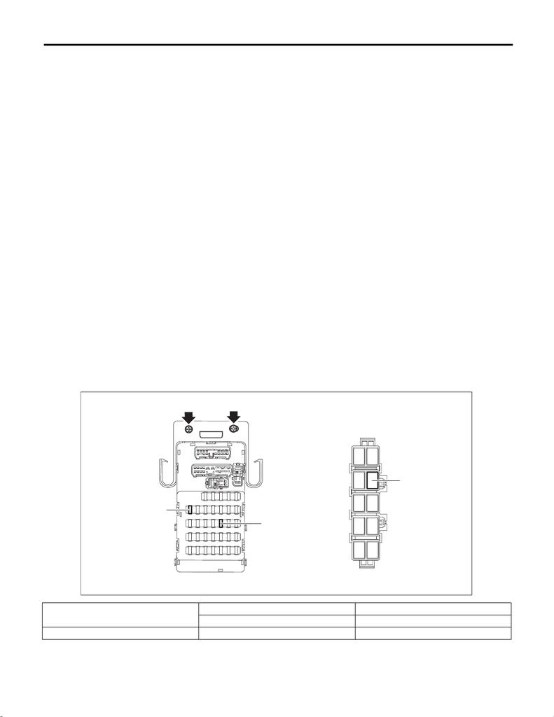

SE-46

Seat Heater System

SEATS

5. Seat Heater System

A: REMOVAL

1. SEAT HEATER UNIT

1) Remove the front seats. <Ref. to SE-9, REMOVAL, Front Seat.>

2) Remove the backrest cover of front seat and seat cushion cover. <Ref. to SE-11, DISASSEMBLY, Front

Seat.>

3) Remove the seat heater unit.

2. SEAT HEATER SWITCH

1) Disconnect the ground cable from battery and wait for at least 60 seconds before starting work. <Ref. to

NT-5, BATTERY, NOTE, Note.>

NOTE:

• For models other than STI model, disconnect the ground terminal from battery sensor.

• On CVT models, shift the select lever into D before disconnecting the battery ground cable.

2) Remove the console box assembly. <Ref. to EI-67, REMOVAL, Console Box.>

3) Remove the screws and remove the seat heater switch from the backside of the console box assembly.

3. SEAT HEATER RELAY AND FUSE

1) Disconnect the ground cable from battery and wait for at least 60 seconds before starting work. <Ref. to

NT-5, BATTERY, NOTE, Note.>

NOTE:

For models other than STI model, disconnect the ground terminal from battery sensor.

2) Remove the cover assembly - instrument panel LWR driver. <Ref. to EI-61, REMOVAL, Instrument Panel

Lower Cover.>

3) Remove the glove box assembly. <Ref. to EI-63, REMOVAL, Glove Box.>

4) Remove the seat heater relay and fuse.

(1) Remove the relay & fuse box bolts.

(2) Remove the seat heater relay from the relay holder.

Relay & fuse box

Fuse 7.5 A (remote control mirror) (A)

Fuse 15 A (seat heater) (B)

Relay holder Seat heater relay (C)

(A)

(B)

(C)

SE-01324

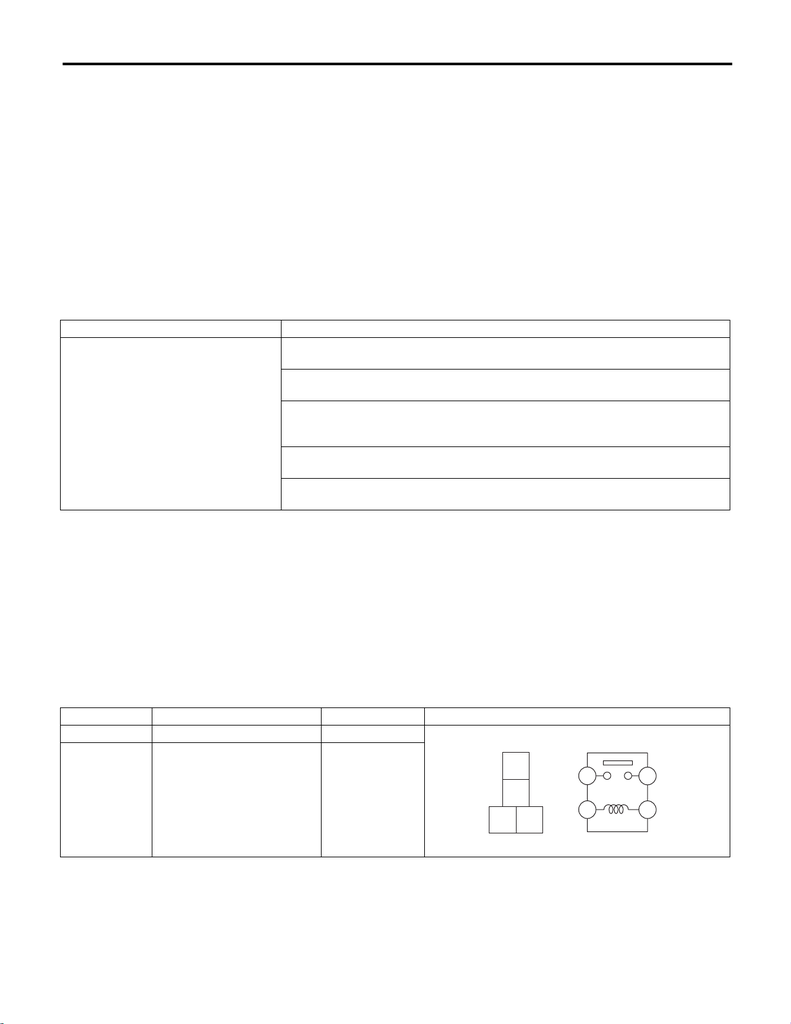

SE-47

Seat Heater System

SEATS

B: INSTALLATION

1) Install the seat heater relay & fuse.

2) Install the globe box assembly.

3) Install the cover assembly - instrument panel LWR driver.

4) Connect the battery ground terminal. <Ref. to NT-5, BATTERY, NOTE, Note.>

NOTE:

For models other than STI model, connect the ground terminal to battery sensor.

C: INSPECTION

1. WIRING DIAGRAM

Refer to “Seat Heater System” in the wiring diagram. <Ref. to WI-370, WIRING DIAGRAM, Seat Heater Sys-

tem.>

3. CHECK SEAT HEATER FUSE

Remove the seat heater fuse and inspect visually.

Is the fuse blown out?

• Yes → Replace the fuse.

• No → Check the power supply and ground circuits.

4. CHECK SEAT HEATER RELAY

1) Remove the seat heater relay from the relay holder.

2) Measure the resistance between seat heater relay terminals.

Preparation tool:

Circuit tester

3) Replace the seat heater relay if the inspection result is not within the standard value.

Symptoms Repair order

Seat heater does not operate.

1. Check the fuse. <Ref. to SE-47, CHECK SEAT HEATER FUSE, INSPECTION, Seat

Heater System.>

2. Check the seat heater relay. <Ref. to SE-47, CHECK SEAT HEATER RELAY,

INSPECTION, Seat Heater System.>

3. Check the seat heater system power supply and ground circuit. <Ref. to SE-48,

CHECK POWER SUPPLY AND GROUND CIRCUIT, INSPECTION, Seat Heater Sys-

tem.>

4. Check the seat heater module. <Ref. to SE-48, SEAT HEATER UNIT, INSPEC-

TION, Seat Heater System.>

5. Check the seat heater switch circuit. <Ref. to SE-49, SEAT HEATER SWITCH,

INSPECTION, Seat Heater System.>

Terminal No. Inspection conditions Standard Circuit

36 — 37 Always 1 MΩ or more

36 — 37

Apply battery voltage between

terminals 38 and 39.

Less than 1 Ω

SE-01325

38

39

36

37

39

38

37

36

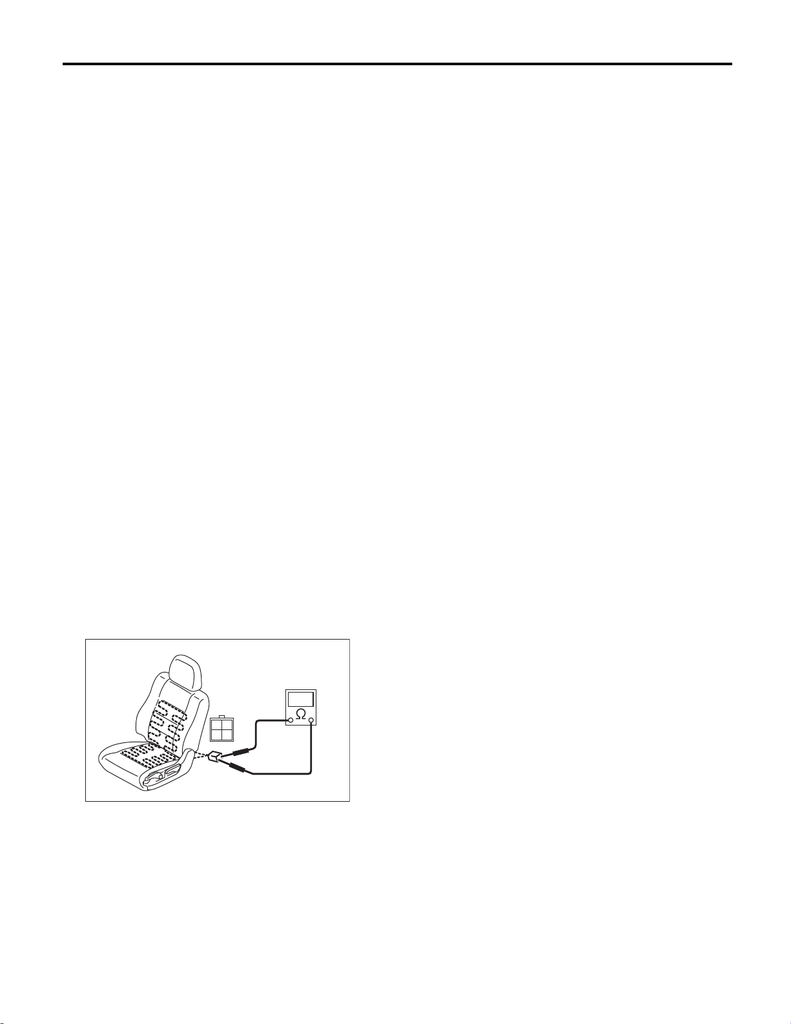

SE-48

Seat Heater System

SEATS

5. CHECK POWER SUPPLY AND GROUND CIRCUIT

1) Check power supply circuit

(1) Disconnect the harness connector of seat heater switch.

(2) Turn the ignition switch to ON.

(3) Measure the voltage between harness connector terminal and chassis ground.

Connector & terminal

(R43) No. 7 (+) — Chassis ground (–):

Is the voltage 12 V or more?

• Yes → Go to step 2.

• No → Check the harness between the seat heater switch and fuse.

2) Check ground circuit

Measure the resistance between harness connector terminal and chassis ground.

Connector & terminal

(R43) No. 2 — Chassis ground:

Is the resistance less than 10 Ω?

• Yes → Go to step 3.

• No → Repair the harness.

Measure the resistance between seat heater switch terminals.

Connector & terminal

(R43) No. 7 — (R43) No. 2:

Is the resistance less than 10 Ω?

• Yes → The power supply and ground circuits are normal.

• No → Replace the seat heater switch.

6. SEAT HEATER UNIT

1) Disconnect the seat heater unit connector, and check the continuity between terminals of connector.

Connector & terminal

HI

No. 1 — No. 3:

No. 3 — No. 4:

LOW

No. 1 — No. 4:

2) If no continuity exists, replace the seat heater module with a new part.

SE-00765

1

2

3

4

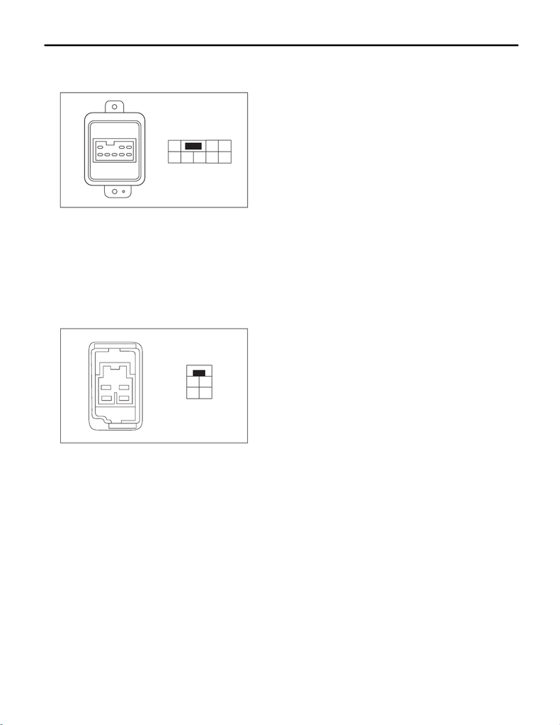

SE-49

Seat Heater System

SEATS

7. SEAT HEATER SWITCH

1) Inspect the continuity between the seat heater switch terminals.

• STI model

Connector & terminal

HI

No. 7 — No. 2:

No. 7 — No. 4:

No. 7 — No. 8:

LOW

No. 7 — No. 1:

No. 7 — No. 2:

No. 7 — No. 3:

• Except for STI model

Connector & terminal

HI

No. 2 — No. 1:

No. 4 — No. 3:

LOW

No. 2 — No. 4:

2) If no continuity exists, replace the seat heater switch with a new part.

SE-01251

12

45

67

3

8

SE-01696

12

34

[figure not shown]

SE-50

Seat Heater System

SEATS

[figure not shown]

SECURITY AND LOCKS

SL

Page

1. General Description ...................................................................................2

2. Relay and Fuse ..........................................................................................8

3. Door Lock Control System .......................................................................10

4. Keyless Entry System ..............................................................................15

5. Keyless Access System ...........................................................................25

6. Push Button Start System ........................................................................26

7. Security System .......................................................................................28

8. Front Inner Remote ..................................................................................32

9. Front Outer Handle ..................................................................................33

10. Front Door Latch and Door Lock Actuator Assembly ...............................37

11. Rear Inner Remote ...................................................................................40

12. Rear Outer Handle ...................................................................................41

13. Rear Door Latch and Door Lock Actuator Assembly ...............................45

14. Trunk Opener Switch ...............................................................................47

15. Trunk Lid Latch and Actuator Assembly ..................................................49

16. Front Hood Lock Assembly ......................................................................51

17. Remote Openers ......................................................................................56

18. Ignition Key Lock ......................................................................................64

19. Key Lock Cylinders ..................................................................................66

20. Security Control Module ...........................................................................72

21. Impact Sensor ..........................................................................................74

22. Keyless Entry Control Module ..................................................................76

23. Keyless Buzzer ........................................................................................77

24. Body Integrated Unit ................................................................................78

25. Keyless Transmitter .................................................................................82

26. Access Key ..............................................................................................85

27. Immobilizer Control Module .....................................................................87

28. Immobilizer Antenna ................................................................................88

29. Keyless Access Indoor Antenna ..............................................................92

30. Keyless Access Outdoor Antenna ............................................................95

31. Trunk Opener Button ................................................................................97

32. Receiver ...................................................................................................98

33. Keyless Access CM ...............................................................................100

34. ID Code Box ...........................................................................................103

35. Steering Lock CM ...................................................................................104

36. Push Button Ignition Switch ...................................................................106

37. Starter Relay (Push Button Start) ...........................................................108

38. IG Relay1 (Push Button Start) ................................................................110

39. IG Relay2 (Push Button Start) ................................................................112

40. Accessory Relay (Push Button Start) .....................................................114

41. Starter Cut Relay ....................................................................................116

42. Access Buzzer .......................................................................................118

43. Function Setting (Customize) .................................................................119

44. Keyless Access With Push Button Start System ....................................120